# hw1_Roger_Casas

Roger Casas

2026-10-07

# Seminar 1 Exercises: Roger Casas Riu

## 8.2.2 Applied Exercise 1

### Maximum Likelihood Estimator

Fitting the model:

```r
fit.mle <- glm('spam.01 ~ .', data = spam, family = binomial(link = 'logit'))
b.mle <- coef(fit.mle)
summary.mle <- summary(fit.mle)
```

#### Which are the selected variables?

- Obtaining a data frame with coefficients and p-values:

```r
b.mle <- data.frame(summary.mle$coefficients[,c(1,4)])
head(b.mle, 10)
```

```
##                      Estimate     Pr...z..
## (Intercept)        -1.5686144 2.349719e-28
## word_freq_make     -0.3895185 9.238799e-02
## word_freq_address  -0.1457768 3.536157e-02
## word_freq_all       0.1141402 3.007594e-01
## word_freq_3d        2.2515195 1.351675e-01
## word_freq_our       0.5623844 3.305708e-08
## word_freq_over      0.8829526 4.087645e-04
## word_freq_remove    2.2785173 7.573083e-12
## word_freq_internet  0.5696134 7.070854e-04
## word_freq_order     0.7342983 9.957524e-03
```

- Filtering for 5% significant coefficients

```r
significant.b.mle <- b.mle[(b.mle[,2] <= 0.05),]
print(glue("Number of significant coefficients is {nrow(significant.b.mle)}"))
```

```
## Number of significant coefficients is 32
```

```r
head(significant.b.mle,3)
```

```
##                     Estimate     Pr...z..
## (Intercept)       -1.5686144 2.349719e-28
## word_freq_address -0.1457768 3.536157e-02
## word_freq_our      0.5623844 3.305708e-08
```

```r
#Names of the significant variables:
rownames(significant.b.mle)
```

```
##  [1] "(Intercept)"                "word_freq_address"
##  [3] "word_freq_our"              "word_freq_over"
##  [5] "word_freq_remove"           "word_freq_internet"
##  [7] "word_freq_order"            "word_freq_free"
##  [9] "word_freq_business"         "word_freq_you"
## [11] "word_freq_your"             "word_freq_000"
## [13] "word_freq_money"            "word_freq_hp"
## [15] "word_freq_hpl"              "word_freq_george"
## [17] "word_freq_650"              "word_freq_data"
## [19] "word_freq_85"               "word_freq_technology"
## [21] "word_freq_pm"               "word_freq_meeting"
## [23] "word_freq_project"          "word_freq_re"
## [25] "word_freq_edu"              "word_freq_conference"
## [27] "`char_freq_;`"              "`char_freq_!`"
## [29] "`char_freq_$`"              "`char_freq_#`"
## [31] "capital_run_length_longest" "capital_run_length_total"
```

#### Predictive accuracy for the MLE

- Generate a Q-(100-Q)% train-test split, for Q = 70 in this case:

```r
Q = 0.7
partsel <- createDataPartition(spam$spam.01, p  = Q, list = FALSE)
train <- spam[partsel,]
test <- spam[-partsel,]
```

- Now fit the model within train data:

```r
fit.mle <- glm('spam.01~.', data = train, family = binomial(link ='logit'))
summary.mle <- summary(fit.mle)
```

- Obtain predicted probabilities and values:

```r
probs <- predict(fit.mle, newdata = test, type = 'response')
preds <- ifelse(probs >= 0.5, 1, 0)
actual <- test$spam.01
```

- Confusion matrix:

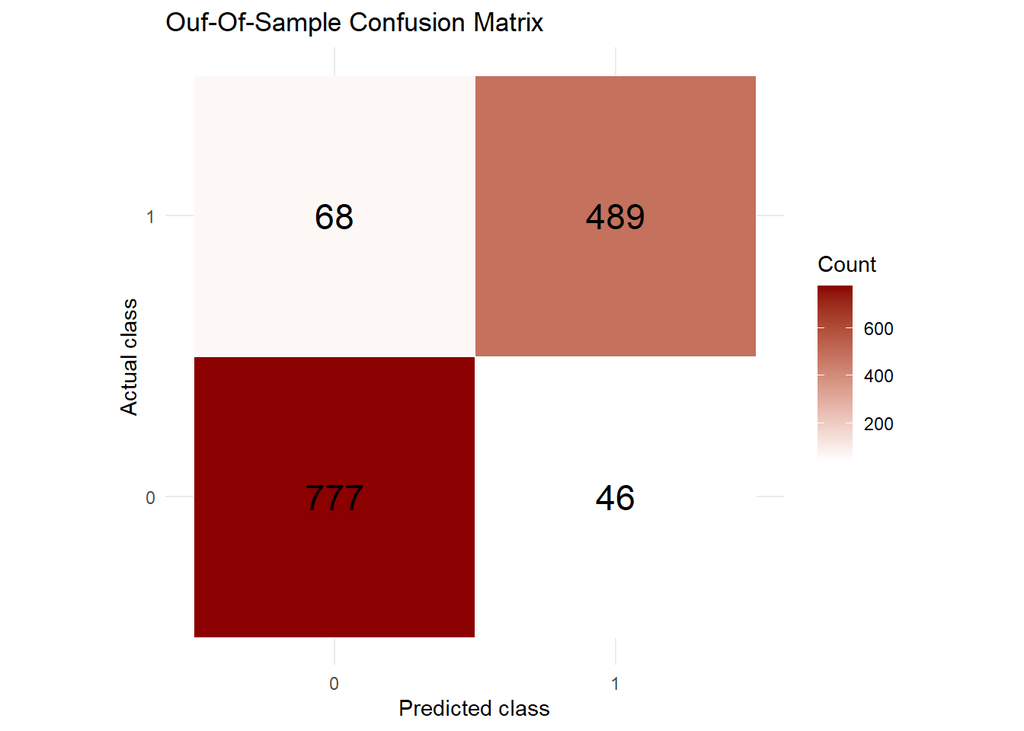

```r
confmatrix <- table(Actual = actual, Predicted = preds)
dfconfmatrix <- as.data.frame(confmatrix)

#Plot for the confusion matrix

confusionplot <-
      ggplot(dfconfmatrix, aes(x = Predicted, y = Actual, fill = Freq)) +
           geom_tile(color = "white") +
           geom_text(aes(label = Freq), size = 6) +
          scale_fill_gradient(low = "white", high = "darkred") +
          labs(
                 title = "Ouf-Of-Sample Confusion Matrix",
                 x = "Predicted class",
                 y = "Actual class",
                fill = "Count"
            ) +
          coord_equal() +
          theme_minimal()


print(confusionplot)
```

- Out-Of-Sample ROC Curve:

```r
roctest <- cbind(test, probs)
roc.mle <- roc(data = roctest, predictor = 'probs', response = 'spam.01' )
```

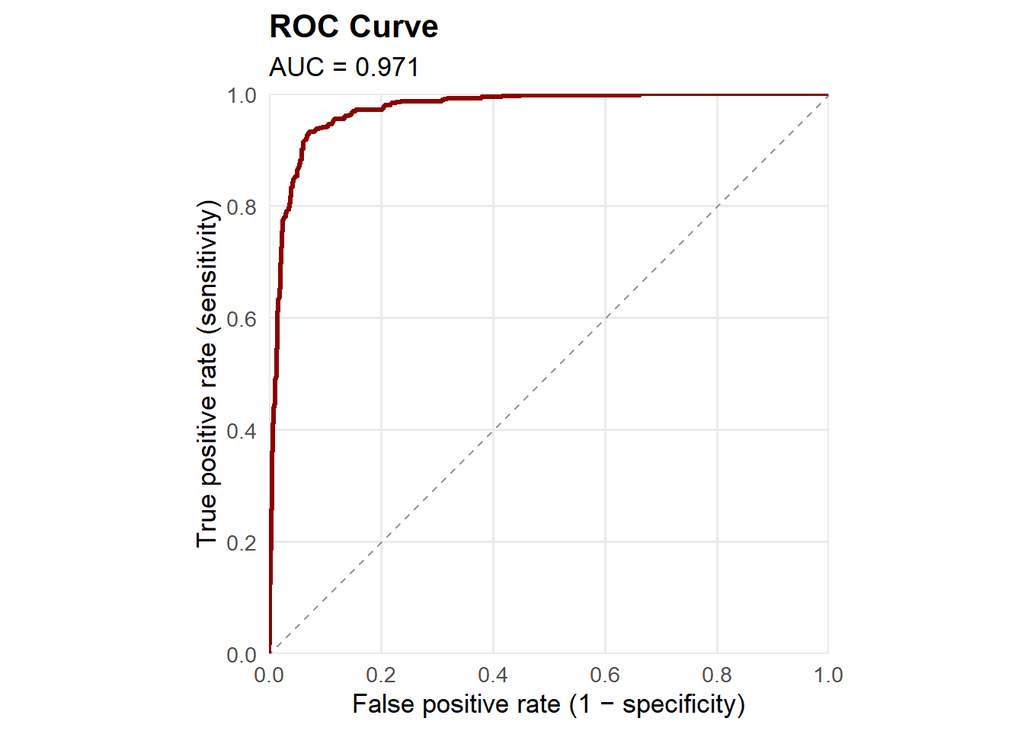

```r
roc_df <- as.data.frame(coords(roc.mle, x = "all", ret = c("specificity", "sensitivity")))

roc_df$false_positive_rate <- 1 - roc_df$specificity
auc_value <- as.numeric(auc(roc.mle))

rocgg <- ggplot(roc_df, aes(x = false_positive_rate, y = sensitivity)) +
      geom_abline(
        slope = 1, intercept = 0,
        linetype = "dashed", color = "grey60"
      ) +
      geom_path(color = "darkred", linewidth = 1.2) +
      coord_equal(xlim = c(0, 1), ylim = c(0, 1), expand = FALSE) +
      scale_x_continuous(breaks = seq(0, 1, by = 0.2)) +
      scale_y_continuous(breaks = seq(0, 1, by = 0.2)) +
      labs(
        title = "ROC Curve",
        subtitle = sprintf("AUC = %.3f", auc_value),
        x = "False positive rate (1 − specificity)",
        y = "True positive rate (sensitivity)"
      ) +
      theme_minimal(base_size = 13) +
      theme(
        panel.grid.minor = element_blank(),
        plot.title = element_text(face = "bold")
      )

print(rocgg)
```

- Store Specificity, Sensitivity, AUC, Accuracy, Brier Score (binary MSPE), and Log-Loss:

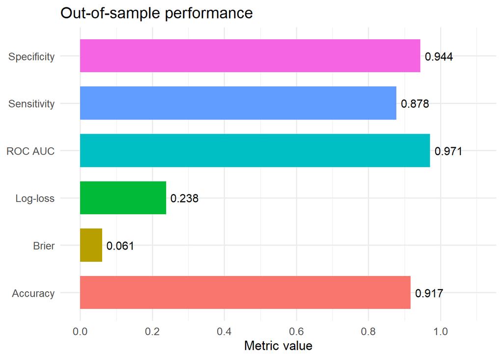

```r
#Notation
TN <- confmatrix[1,1]
FN <- confmatrix[2,1]
FP <- confmatrix[1,2]
TP <- confmatrix[2,2]

#Calculations
Spec <- TN/(TN+FP)
Sens <- TP/(TP+FN)
AUC <- as.numeric(roc.mle$auc)
Accuracy <- (TP+TN)/(TN+FP+TP+FN)
Brier <- mean((test$spam.01-probs)^2)

y <- as.numeric(test$spam.01)
eps <- 1e-15
probs_safe <- pmin(pmax(probs, eps), 1 - eps)
Logloss <- -mean(
  y * log(probs_safe) + (1 - y) * log(1 - probs_safe)
)


#Constructing the data frame
performance <- c(Spec,Sens,Accuracy, AUC ,Brier, Logloss ) |> as.data.frame( ,row.names = c('Specificity', 'Sensitivity', 'Accuracy', 'ROC AUC' , 'Brier', 'Log-loss'))
colnames(performance) <- c('OOS Value')
#Ggplot

metrics <- data.frame(
    Metric = rownames(performance),
    OOS_Value = performance[,1])

metricsgg <- ggplot(metrics,aes(x = Metric,y = OOS_Value,fill = Metric)
  ) +
    geom_col(width = 0.7, show.legend = FALSE) +
    geom_text(aes(label = sprintf("%.3f", OOS_Value)),hjust = -0.15,size = 4) +
    coord_flip() +
    scale_y_continuous(
      limits = c(0,1.1),
      breaks = seq(0, 1, by = 0.2)
    ) +
    labs(
      title = "Out-of-sample performance",
      x = NULL,
      y = "Metric value"
    ) +
    theme_minimal(base_size = 13)

print(metricsgg)
```

```r
#Recover number of non-zero coefficients (either significant or not) and append it to performance data.frame:

Mle.Nvariables <- as.integer(sum((fit.mle$coefficients != 0)))
performance <- t(performance) |> as.data.frame()
rownames(performance) <- c("OOS Value")
colnames(performance) <- c('Specificity', 'Sensitivity', 'Accuracy', 'ROC AUC' , 'Brier', 'Log-loss')
performance["N-Variables"] <- as.integer(Mle.Nvariables)
performance
```

```
##           Specificity Sensitivity  Accuracy   ROC AUC      Brier  Log-loss
## OOS Value   0.9441069   0.8779174 0.9173913 0.9714274 0.06067916 0.2382254
##           N-Variables
## OOS Value          58
```

- Make the performance evaluation a callable function for next sections

```r
performance_eval <- function(preds, probs, actual = test$spam.01){
confmatrix <- table(Actual = actual, Predicted = preds)
dfconfmatrix <- as.data.frame(confmatrix)
#Plot for the confusion matrix:
confusionplot <-
      ggplot(dfconfmatrix, aes(x = Predicted, y = Actual, fill = Freq)) +
           geom_tile(color = "white") +
           geom_text(aes(label = Freq), size = 6) +
          scale_fill_gradient(low = "white", high = "darkred") +
          labs(
                 title = "Ouf-Of-Sample Confusion Matrix",
                 x = "Predicted class",
                 y = "Actual class",
                fill = "Count"
            ) +
          coord_equal() +
          theme_minimal()
print(confusionplot)
#Out-Of-Sample ROC Curve:
roctest <- cbind(test, probs)
rocobject <- roc(data = roctest, predictor = 'probs', response = 'spam.01' )
roc_df <- as.data.frame(coords(rocobject, x = "all", ret = c("specificity", "sensitivity")))
roc_df$false_positive_rate <- 1 - roc_df$specificity
auc_value <- as.numeric(auc(rocobject))
rocgg <- ggplot(roc_df, aes(x = false_positive_rate, y = sensitivity)) +
      geom_abline(
        slope = 1, intercept = 0,
        linetype = "dashed", color = "grey60"
      ) +
      geom_path(color = "darkred", linewidth = 1.2) +
      coord_equal(xlim = c(0, 1), ylim = c(0, 1), expand = FALSE) +
      scale_x_continuous(breaks = seq(0, 1, by = 0.2)) +
      scale_y_continuous(breaks = seq(0, 1, by = 0.2)) +
      labs(
        title = "ROC Curve",
        subtitle = sprintf("AUC = %.3f", auc_value),
        x = "False positive rate (1 − specificity)",
        y = "True positive rate (sensitivity)"
      ) +
      theme_minimal(base_size = 13) +
      theme(
        panel.grid.minor = element_blank(),
        plot.title = element_text(face = "bold")
      )

print(rocgg)
# Store Specificity, Sensitivity, AUC, Accuracy, Brier Score (binary MSPE), and Log-Loss:
#Notation
TN <- confmatrix[1,1]
FN <- confmatrix[2,1]
FP <- confmatrix[1,2]
TP <- confmatrix[2,2]
#Calculations
Spec <- TN/(TN+FP)
Sens <- TP/(TP+FN)
AUC <- as.numeric(rocobject$auc)
Accuracy <- (TP+TN)/(TN+FP+TP+FN)
Brier <- mean((test$spam.01-probs)^2)
y <- as.numeric(test$spam.01)
eps <- 1e-15
probs_safe <- pmin(pmax(probs, eps), 1 - eps)
Logloss <- -mean(
  y * log(probs_safe) + (1 - y) * log(1 - probs_safe)
)

#Constructing the data frame
performance <- c(Spec,Sens,Accuracy, AUC ,Brier, Logloss ) |> as.data.frame( ,row.names = c('Specificity', 'Sensitivity', 'Accuracy', 'ROC AUC' , 'Brier', 'Log-loss'))
colnames(performance) <- c('OOS Value')
#Ggplot
metrics <- data.frame(
    Metric = rownames(performance),
    OOS_Value = performance[,1])

metricsgg <- ggplot(metrics,aes(x = Metric,y = OOS_Value,fill = Metric)
  ) +
    geom_col(width = 0.7, show.legend = FALSE) +
    geom_text(aes(label = sprintf("%.3f", OOS_Value)),hjust = -0.15,size = 4) +
    coord_flip() +
    scale_y_continuous(
      limits = c(0,1.1),
      breaks = seq(0, 1, by = 0.2)
    ) +
    labs(
      title = "Out-of-sample performance",
      x = NULL,
      y = "Metric value"
    ) +
    theme_minimal(base_size = 13)
print(metricsgg)
return(performance)
}
```

### Cross - Validated LASSO

#### Which are the selected variables?

- Fitting the model:

```r
designmat <- as.matrix(spam[,-ncol(spam)])
cvlasso.fit <- cv.glmnet(x = designmat, y = spam$spam.01, nfolds = 10,family = 'binomial')
```

- Selected variables:

```r
# Coefficients at the lambda with minimum cross-validation error
coef_mat <- as.matrix(coef(cvlasso.fit, s = "lambda.min"))

# Exclude the intercept when identifying selected predictors
is_predictor <- rownames(coef_mat) != "(Intercept)"
selected <- is_predictor & coef_mat[, 1] != 0

cvlasso.nonzero <- data.frame(
  Variable = rownames(coef_mat)[selected],
  Coefficient = coef_mat[selected, 1],
  row.names = NULL
)

cvlasso.zero <- data.frame(
  Variable = rownames(coef_mat)[is_predictor & !selected],
  Coefficient = coef_mat[is_predictor & !selected, 1],
  row.names = NULL
)

print(glue("Number of selected predictors: {nrow(cvlasso.nonzero)}"))
```

```
## Number of selected predictors: 54
```

```r
cvLasso.Nvariables <- nrow(cvlasso.nonzero)
head(cvlasso.nonzero,5)
```

```
##            Variable Coefficient
## 1    word_freq_make  -0.2939215
## 2 word_freq_address  -0.1368028
## 3     word_freq_all   0.1397054
## 4      word_freq_3d   0.2827671
## 5     word_freq_our   0.5370670
```

#### Predictive accuracy

- Fit Lasso for Train Data

```r
traindesign <- designmat[partsel,]
testdesign <- designmat[-partsel,]
cvlasso.fit <- cv.glmnet(x = traindesign, y = train$spam.01, nfolds = 10,family = 'binomial')
```

- Obtain “preds” “probs” and “actual”

```r
probabilities <- predict(cvlasso.fit, newx = testdesign, s = 'lambda.min', type = 'response')[,1]
predictions <- ifelse(probabilities >= 0.5, 1, 0)
actual <- test$spam.01 #Redundant actually
```

- Call the previous function (see the MLE section) to obtain Out-Of-Sample Performance Metrics:

```r
cvlasso.performance <- performance_eval(preds =predictions, probs = probabilities)
```

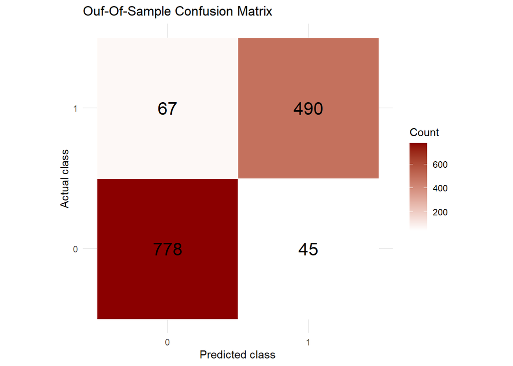

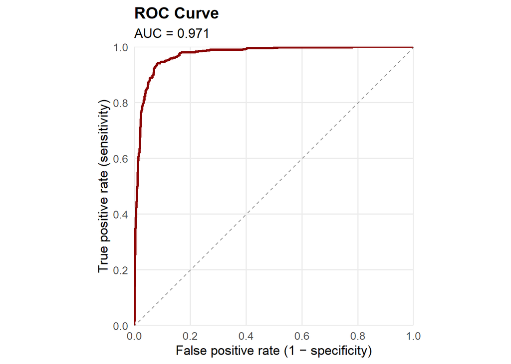

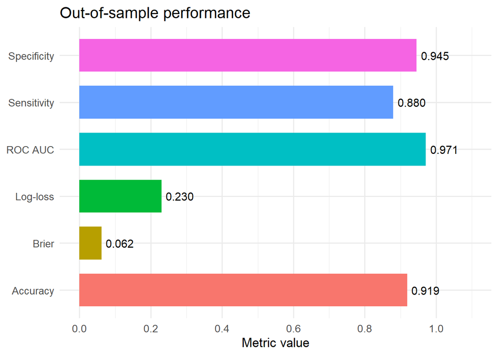

- Append the number of surviving covariates to the performance data.frame for later comparison

```r
cvlasso.performance <- t(cvlasso.performance) |> as.data.frame()
rownames(cvlasso.performance) <- c("OOS Value")
colnames(cvlasso.performance) <- c('Specificity', 'Sensitivity', 'Accuracy', 'ROC AUC' , 'Brier', 'Log-loss')
cvlasso.performance["N-Variables"] <- as.integer(cvLasso.Nvariables)
cvlasso.performance
```

```
##           Specificity Sensitivity  Accuracy   ROC AUC      Brier  Log-loss
## OOS Value    0.945322   0.8797127 0.9188406 0.9711329 0.06172059 0.2301015
##           N-Variables
## OOS Value          54
```

### BIC - LASSO

#### Which are the selected variables?

- Set modify the routines function for logistic regression:

```r
lasso_bic_binomial <- function(y, x, x_test = testdesign) {
  fit <- glmnet(x = x, y = y, family = "binomial", alpha = 1)

  # Use training data to select lambda by BIC
  eta_train <- predict(fit, newx = x, s = fit$lambda, type = "link")
  probs_train <- pmin(pmax(plogis(eta_train), 1e-15), 1 - 1e-15)
  loglik <- colSums(y * log(probs_train) + (1 - y) * log(1 - probs_train))

  n <- length(y)
  n_selected <- colSums(as.matrix(fit$beta) != 0)
  df <- n_selected + 1
  bic <- -2 * loglik + log(n) * df

  best <- which.min(bic)
  lambda_opt <- fit$lambda[best]

  coef <- as.matrix(coef(fit, s = lambda_opt))[, 1]
  names(coef)[names(coef) == "(Intercept)"] <- "Intercept"

  ypred_logodds <- as.numeric(
    predict(fit, newx = x_test, s = lambda_opt, type = "link")
  )
  ypred <- plogis(ypred_logodds)

  output <- list(
    coef = coef,
    ypred = ypred,
    ypred_logodds = ypred_logodds,
    lambda.opt = lambda_opt,
    lambda = data.frame(
      lambda = fit$lambda,
      bic = bic,
      nvars = n_selected),
    fit = fit
  )
  return(output)
}
```

- Fitting the model:

```r
biclasso.fit <- lasso_bic_binomial(x = designmat, y = spam$spam.01)
```

- Selected variables:

```r
# Coefficients at the lambda with minimum cross-validation error
biclasso.coefs <- biclasso.fit$coef |> as.data.frame()

biclasso.nonzero <- filter(biclasso.coefs, (biclasso.fit$coef !=0) & (rownames(biclasso.coefs) != "Intercept"))
colnames(biclasso.nonzero) <- 'Estimate'

biclasso.Nvariables <- nrow(biclasso.nonzero)

print(glue("Number of selected predictors:{nrow(biclasso.nonzero)}"))
```

```
## Number of selected predictors:54
```

```r
biclasso.nonzero
```

```
##                                 Estimate
## word_freq_make             -3.263547e-01
## word_freq_address          -1.482761e-01
## word_freq_all               1.313653e-01
## word_freq_3d                9.021149e-01
## word_freq_our               5.605974e-01
## word_freq_over              7.911125e-01
## word_freq_remove            2.309898e+00
## word_freq_internet          5.627751e-01
## word_freq_order             6.121358e-01
## word_freq_mail              1.223651e-01
## word_freq_receive          -2.341861e-01
## word_freq_will             -1.435521e-01
## word_freq_people           -7.484893e-02
## word_freq_report            1.217185e-01
## word_freq_addresses         1.183073e+00
## word_freq_free              1.036095e+00
## word_freq_business          9.094343e-01
## word_freq_email             1.201526e-01
## word_freq_you               7.905902e-02
## word_freq_credit            1.008818e+00
## word_freq_your              2.409232e-01
## word_freq_font              2.223037e-01
## word_freq_000               2.261991e+00
## word_freq_money             4.791739e-01
## word_freq_hp               -1.842207e+00
## word_freq_hpl              -1.038754e+00
## word_freq_george           -5.006048e+00
## word_freq_650               4.166900e-01
## word_freq_lab              -1.916425e+00
## word_freq_labs             -3.084593e-01
## word_freq_telnet           -1.995914e-01
## word_freq_data             -8.115933e-01
## word_freq_85               -1.830254e+00
## word_freq_technology        8.871144e-01
## word_freq_parts            -5.573769e-01
## word_freq_pm               -7.977985e-01
## word_freq_direct           -3.048222e-01
## word_freq_cs               -1.079216e+01
## word_freq_meeting          -2.242619e+00
## word_freq_original         -1.042538e+00
## word_freq_project          -1.478633e+00
## word_freq_re               -7.541290e-01
## word_freq_edu              -1.411610e+00
## word_freq_table            -2.180729e+00
## word_freq_conference       -3.263934e+00
## char_freq_;                -1.246292e+00
## char_freq_(                -1.594393e-01
## char_freq_[                -6.586425e-01
## char_freq_!                 3.728980e-01
## char_freq_$                 5.246335e+00
## char_freq_#                 2.183079e+00
## capital_run_length_average -5.659299e-03
## capital_run_length_longest  6.985944e-03
## capital_run_length_total    7.692804e-04
```

#### Predictive accuracy

- Fit BIC - Lasso for Train Data and predict for Test Data (the function returns predicted OOS output automatically):

```r
biclasso.fit <- lasso_bic_binomial(x = traindesign, y = train$spam.01, x_test = testdesign)
```

- Obtain “preds” “probs” and “actual”:

```r
probabilities <- biclasso.fit$ypred
predictions <- ifelse(probabilities >= 0.5, 1, 0)
actual <- test$spam.01 #Redundant actually
```

- Call the previous function to obtain Out-Of-Sample Performance Metrics:

```r
biclasso.performance <- performance_eval(preds =predictions, probs = probabilities)
```

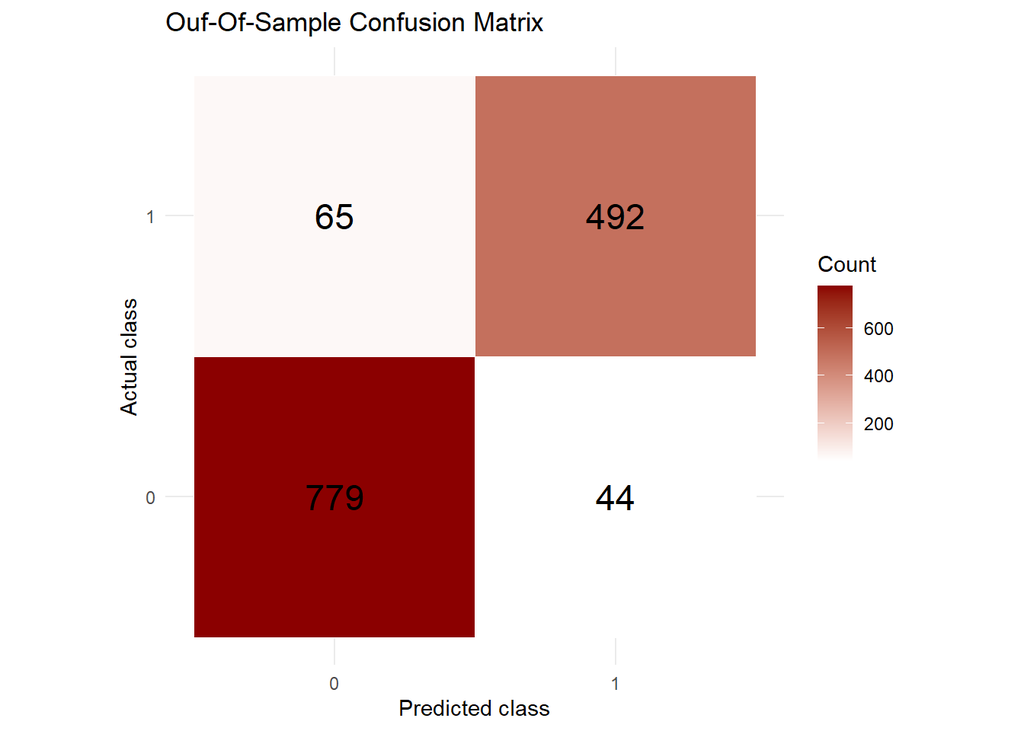

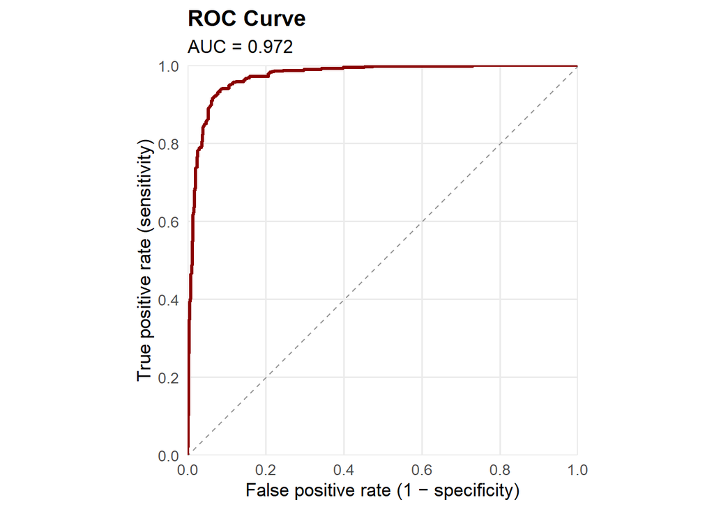

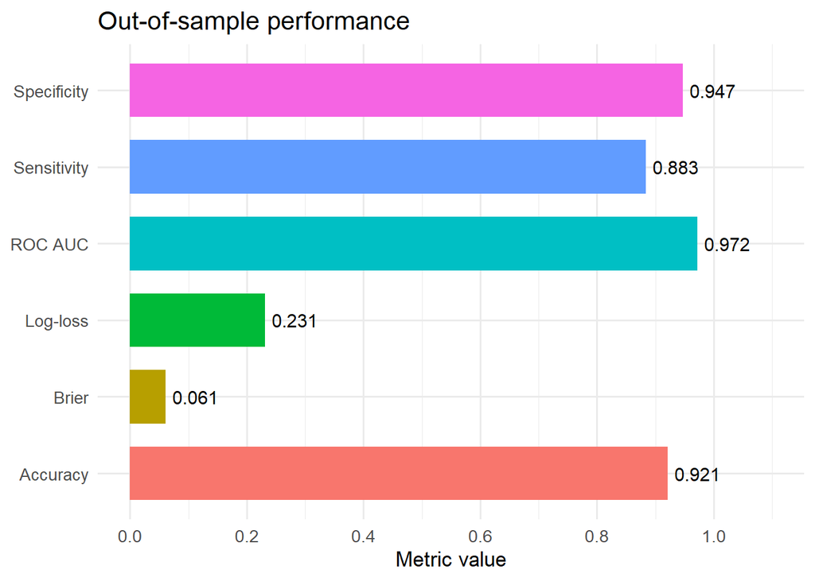

- Append the number of surviving covariates to the performance data.frame for later comparison:

```r
biclasso.performance <- t(biclasso.performance) |> as.data.frame()
rownames(biclasso.performance) <- c("OOS Value")
colnames(biclasso.performance) <- c('Specificity', 'Sensitivity', 'Accuracy', 'ROC AUC' , 'Brier', 'Log-loss')
biclasso.performance["N-Variables"] <- as.integer(biclasso.Nvariables)
biclasso.performance
```

```
##           Specificity Sensitivity  Accuracy   ROC AUC      Brier  Log-loss
## OOS Value   0.9465371   0.8833034 0.9210145 0.9715823 0.06073519 0.2313169
##           N-Variables
## OOS Value          54
```

### Final comparison and answer. Which model to select?

```r
finalperformance <- performance |> rbind(cvlasso.performance[1,], biclasso.performance[1,])
finalperformance$Type <- c('MLE', 'CV - LASSO', 'BIC - LASSO')
rownames(finalperformance) <- c('OOS - MLE','OOS - CVLASSO', 'OOS - BICLASSO')
finalperformance
```

```
##                Specificity Sensitivity  Accuracy   ROC AUC      Brier  Log-loss
## OOS - MLE        0.9441069   0.8779174 0.9173913 0.9714274 0.06067916 0.2382254
## OOS - CVLASSO    0.9453220   0.8797127 0.9188406 0.9711329 0.06172059 0.2301015
## OOS - BICLASSO   0.9465371   0.8833034 0.9210145 0.9715823 0.06073519 0.2313169
##                N-Variables        Type
## OOS - MLE               58         MLE
## OOS - CVLASSO           54  CV - LASSO
## OOS - BICLASSO          54 BIC - LASSO
```

- A concluding plot:

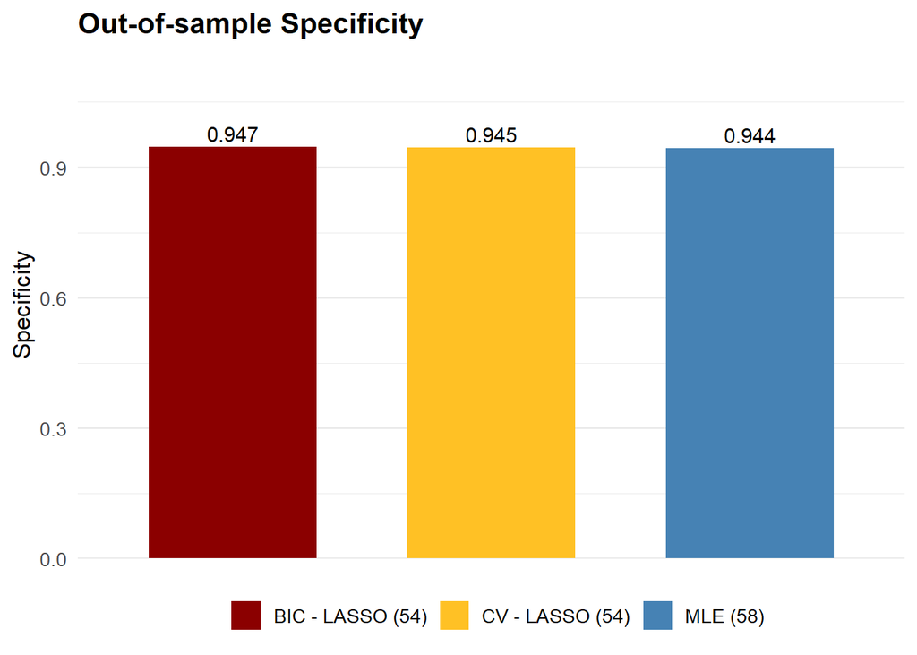

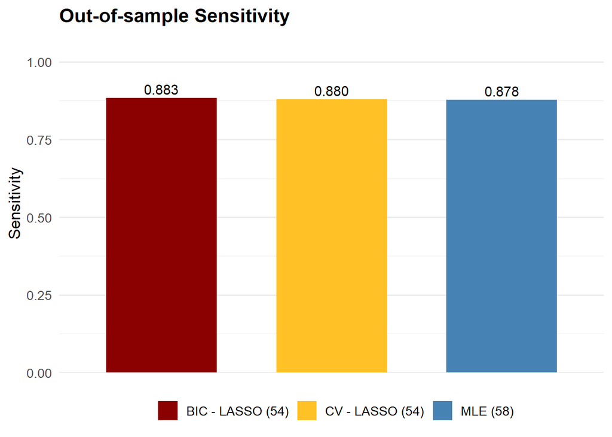

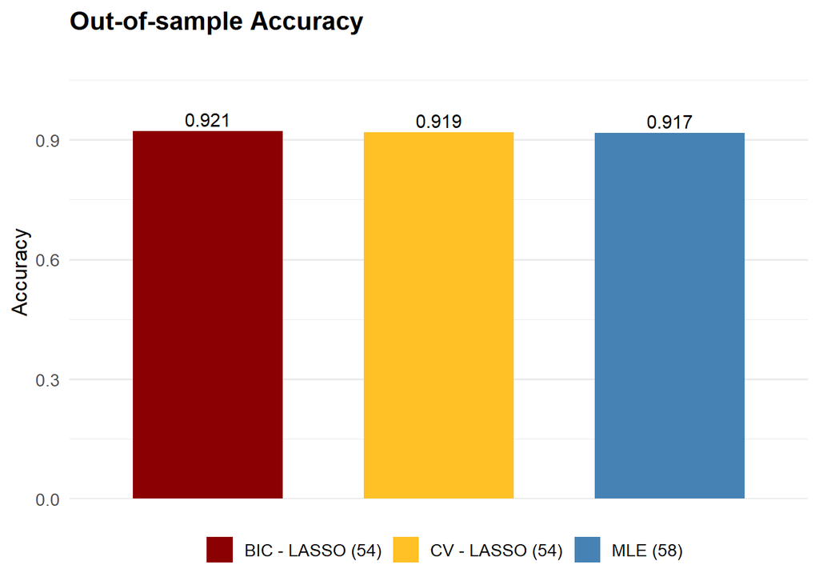

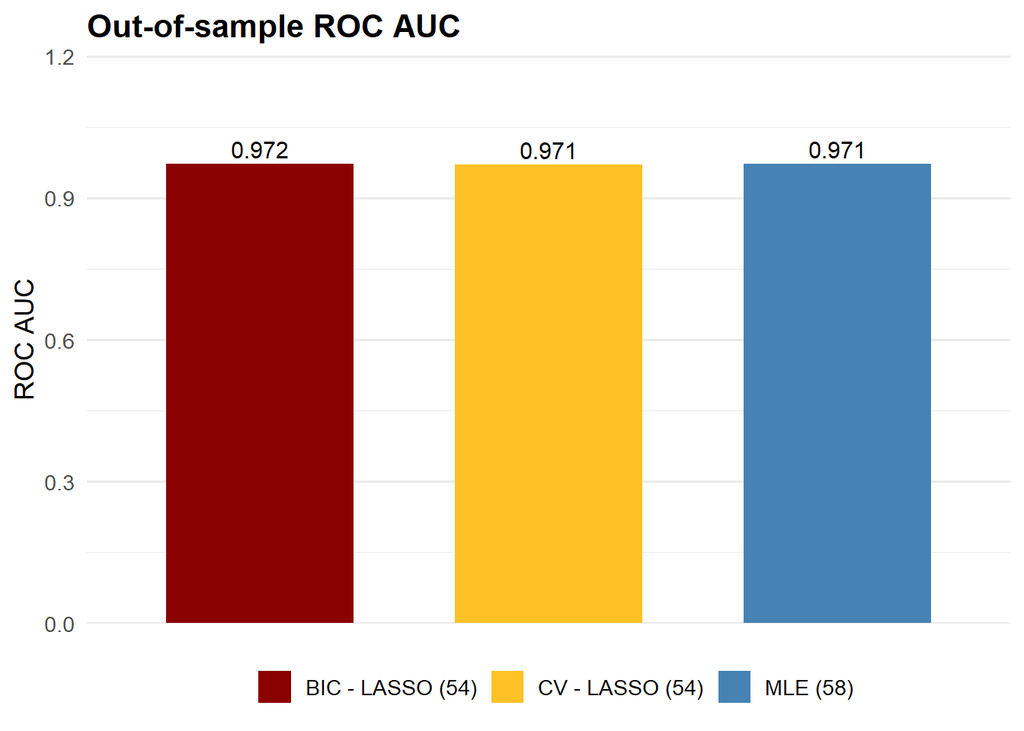

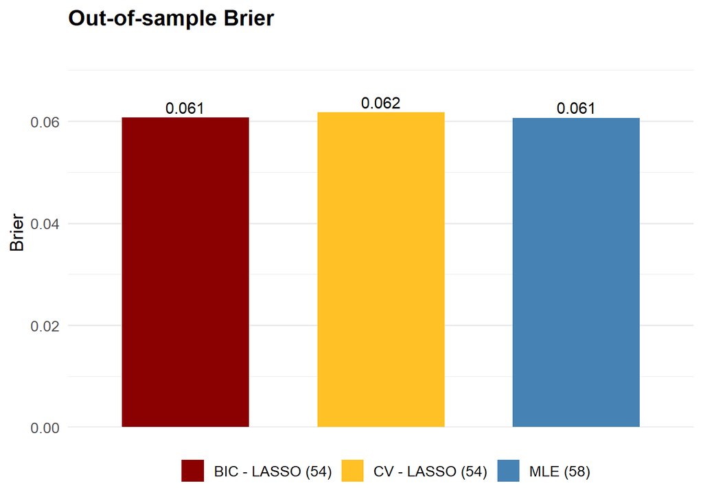

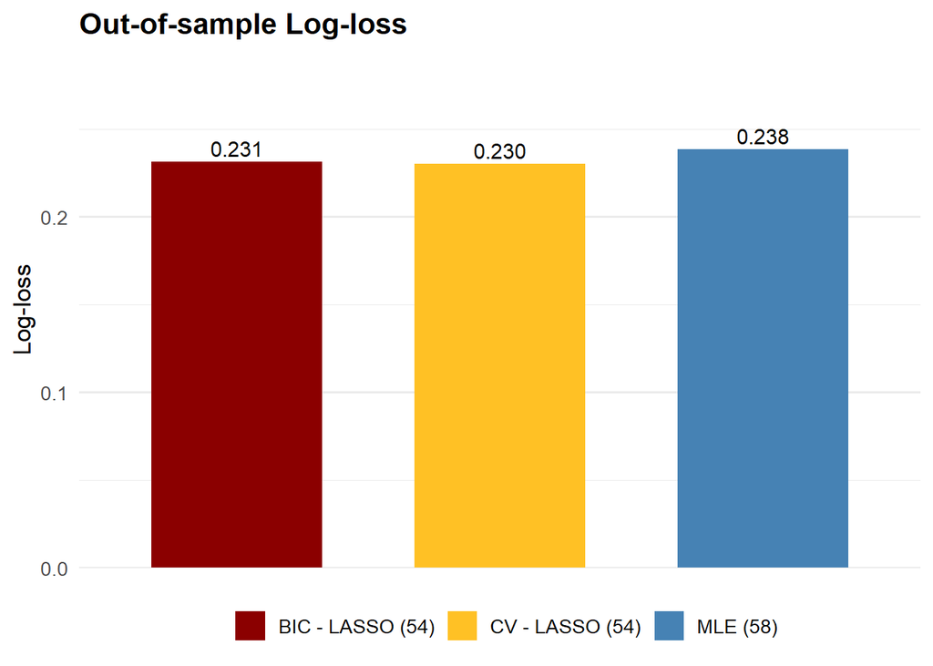

```r
metric_cols <- names(finalperformance)[1:6]
n_models <- nrow(finalperformance)

plot_data <- data.frame(
  Metric = rep(metric_cols, each = n_models),
  Value = as.numeric(as.matrix(finalperformance[, metric_cols])),
  Model = rep(rownames(finalperformance), times = length(metric_cols)),
  Type = rep(finalperformance$Type, times = length(metric_cols)),
  N_Variables = rep(finalperformance$`N-Variables`, times = length(metric_cols))
)

plot_data$Legend <- paste0(
  plot_data$Type, " (", plot_data$N_Variables, ")"
)

metric_plots <- lapply(metric_cols, function(metric_name) {
  metric_data <- plot_data[plot_data$Metric == metric_name, ]
  upper_limit <- max(metric_data$Value, na.rm = TRUE) * 1.2

  legend_names <- unique(plot_data$Legend)
  model_colors <- c("steelblue", "goldenrod1", "darkred")
  names(model_colors) <- legend_names

  ggplot(metric_data, aes(x = Model, y = Value, fill = Legend)) +
    geom_col(width = 0.65) +
    geom_text(
      aes(label = sprintf("%.3f", Value)),
      vjust = -0.35,
      size = 4
    ) +
    scale_fill_manual(values = model_colors) +
    scale_y_continuous(
      limits = c(0, upper_limit),
      expand = expansion(mult = c(0, 0.03))
    ) +
    labs(
      title = paste("Out-of-sample", metric_name),
      x = NULL,
      y = metric_name,
      fill = NULL
    ) +
    theme_minimal(base_size = 13) +
    theme(
      legend.position = "bottom",
      axis.text.x = element_blank(),
      axis.ticks.x = element_blank(),
      panel.grid.major.x = element_blank(),
      plot.title = element_text(face = "bold")
    )
})

names(metric_plots) <- metric_cols

for (p in metric_plots) {
  print(p)
}
```

## Answer:

Overall, computed differences in model performance seem nearly negligible. However, if substantial concretion is expected, the BIC approach appears to be the most sensible election when considering all Out-Of-Sample metrics as a whole. For weighted measures like the Log-Loss, however, the Cross-Validated Lasso also arises as a suitable candidate.

It is worth emphasizing, in this sense, that the Specificity-Sensitivity trade-off proposed by the BIC algorithm is more suitable considering the theoretical context of the case. As the BIC reports higher Specificity, it reduces the probability of Type I error occurring (i.e. of non-spam emails incorrectly being labeled as spam). The consequences of a non-spam email being discarded are worse in terms of the user’s utility than those of a Type II setting (a spam email appearing in the main inbox). Therefore, Specificity deserves special consideration regarding the final decision for a research paper.

Inference-wise, moreover, model-selection consistency is to be taken into account as a positive trait of the BIC as well. It also entails a non-negligibly more parsimonious equation than the MLE (54 vs 58 variables), while difference with respect to the Cross-Validated Lasso is omittable. When computing confidence intervals and significance tests, however, the MLE estimator behaves much better.

Ultimately, for the aforementioned reasons, the BIC appears to offer an optimal trade-off between all the dimensions analyzed, especially for predictive purposes. Running time for the different algorithms may also help one decide between the three methodologies when dealing with a larger amount of rows (observations) or columns (variables) of the problem’s design matrix.

## 8.2.2 Applied Exercise 2

### 8.2.3.1 Data and Context:

```r
data(epil, package = "MASS")

# Keep only one row per subject (period 1) to avoid repeated measures
df <- epil %>%
  dplyr::filter(period == 1) %>%
  dplyr::select(y, base)

dim(df)
```

```
## [1] 59  2
```

### 8.2.3.2 Train/Test Split and Models

- Which model is better?

Your answer: The model including base performs better.

```r
set.seed(42)

poisson_nll_vec <- function(y, mu) {
  # vectorized Poisson negative log-likelihood
  # uses lgamma(y+1) for log(y!)
  mu - y * log(mu) + lgamma(y + 1)
}

one_split_eval <- function(df, test_frac = 0.1) {
  n <- nrow(df)
  test_idx <- sample.int(n, size = ceiling(test_frac * n))
  test <- df[test_idx, , drop = FALSE]
  train <- df[-test_idx, , drop = FALSE]

  ###########################
  # COMPLETE THE CODE BELOW #
  ###########################

  # Fit models on train
  m0 <-  glm(y~1, family = poisson(), data = train)         # intercept-only
  m1 <- glm(y~base, family = poisson(), data = train)      # with covariate

  # Predict means on test
  mu0_test <- predict(m0, newdata = test, type = 'response')         # intercept-only test set prediction
  mu1_test <- predict(m1, newdata = test, type = 'response')        # with covariate test set prediction

  # Compute mean test NLL
  nll0 <- mean(poisson_nll_vec(y = test$y, mu = mu0_test))              # intercept-only
  nll1 <- mean(poisson_nll_vec(y = test$y, mu = mu1_test))             # with covariate

  list(nll0 = nll0, nll1 = nll1, n_test = nrow(test))
}

res1 <- one_split_eval(df, test_frac = 0.1)
res1
```

```
## $nll0
## [1] 33.28513
##
## $nll1
## [1] 4.083654
##
## $n_test
## [1] 6
```

###8.2.3.3 Estimating the Expected Out-of-Sample Log-Likelihood Loss

####Question B. Based on the repeated splits: What is the estimated expected average test NLL for each model? Provide the estimate and a standard error.

-Your answer:

```r
R <- 1000
out <- replicate(R, {
  tmp <- one_split_eval(df, test_frac = 0.1)
  c(nll0 = tmp$nll0, nll1 = tmp$nll1)
})

out <- t(out) %>% as.data.frame()
colnames(out) <- c("nll0", "nll1")


#We use the sample average and standard deviations as sensible estimators for the true expectation and standard error resquested:

m0_nll_avg <- mean(out$nll0)
m0_nll_sd <- sd(out$nll0)/sqrt(R)

m1_nll_avg <- mean(out$nll1)
m1_nll_sd <- sd(out$nll1)/sqrt(R)



# Provide an estimate and a standard error for the expected average NLL for each model

print(glue("m0 average : {m0_nll_avg}
            m0 standard error: {m0_nll_sd}
            m1 average: {m1_nll_avg}
            m1 standard error:  {m1_nll_sd}"
))
```

```
## m0 average : 8.48380036609779
## m0 standard error: 0.282257504175004
## m1 average: 3.76866390285763
## m1 standard error:  0.0516494835338154
```

####8.2.3.3.1 Visualizing the Distribution of Test NLLs Across Splits

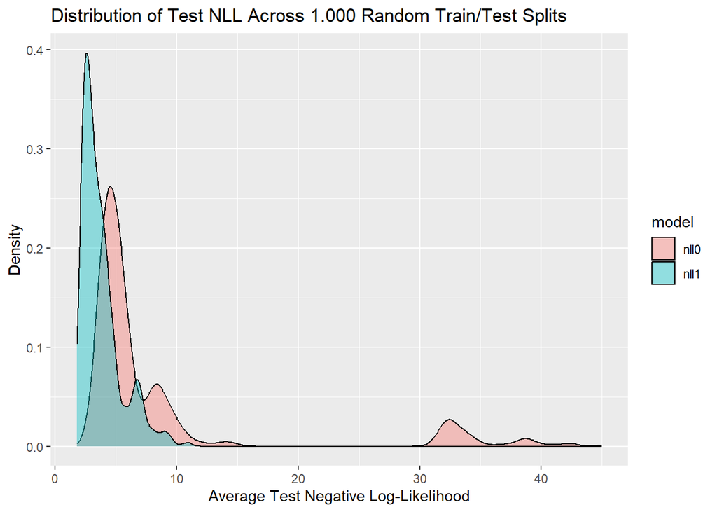

```r
out_long <- out %>%
  tidyr::pivot_longer(cols = everything(),
                      names_to = "model",
                      values_to = "test_nll")

ggplot(out_long, aes(x = test_nll, fill = model)) +
  geom_density(alpha = 0.4) +
  labs(title = "Distribution of Test NLL Across 1.000 Random Train/Test Splits",
       x = "Average Test Negative Log-Likelihood",
       y = "Density")
```

###8.2.3.4 Cross-Validation Check (k-fold)

Question C. Do the CV results agree with the repeated-split results?

-Your answer: Yes, the the model including base reports a much better performance.

```r
kfold_cv <- function(df, k = 10) {
  n <- nrow(df)
  fold_id <- sample(rep(1:k, length.out = n))
  res <- lapply(1:k, function(kid) {
    test <- df[fold_id == kid, , drop = FALSE]
    train <- df[fold_id != kid, , drop = FALSE]

    m0 <- glm(y ~ 1, data = train, family = poisson())
    m1 <- glm(y ~ base, data = train, family = poisson())

    mu0_test <- predict(m0, newdata = test, type = "response")
    mu1_test <- predict(m1, newdata = test, type = "response")

    c(
      nll0 = mean(poisson_nll_vec(test$y, mu0_test)),
      nll1 = mean(poisson_nll_vec(test$y, mu1_test))
    )
  })

  mat <- do.call(rbind, res)
  colMeans(mat)
}

set.seed(42)
cv_res <- kfold_cv(df, k = 10)
cv_res
```

```
##     nll0     nll1
## 8.293240 3.708265
```